# 통계 방법론Ⅱ - 탐색적 데이터 분석

응용통계학과 이준혁

2023-06-10(토)

# Ch11. 시각화(Visualization)

- Numerical quantities focus on expected value, graphical summaries on unexpected values.
- EDA의 현시성(Revelation)은 데이터 탐색을 위하여 다양한 정보들에 대한 그래픽 요약(graphical summary)을 강조한다.
- 그래프(graphs)는 의도된 메시지의 생생함, 불가피성 그리고 숫자들만으로 표현할 수 없는 정보들을 표현할 수 있어야 한다.
- 데이터 시각화의 목적, 목표 그리고 설계 원칙
  - 최근의 데이터 시각화 방법들은 데이터의 분석에 기반하고 있다.
  - 좁은 의미에서는 **EDA 시각화**는 **분석-탐색-탐지**를 위하여 적용된다.
  - 목적과 목표를 달성하기 위한 기초 작업의 역할을 수행한다.

| 목적 | 목표 | 시각화 설계 원칙 |
| --- | --- | --- |
| 분석 (Analysis) | 탐색 (Exploration) | 탐지 (Detection) |
|  | 수색 (Reconnaissance) | 인지 (Perception) |
|  | 진단 (Diagnosis) | 비교 (Comparison) |
| 소개 (Presentation) | 예증 (To Simulate) | 미학 (Aesthetics) |
|  | 설득 (To Persuade) | 수사 (Rhetoric) |
|  | 알림 (To inform) | 설득 (Exposition) |

- 효과적인 그래픽 요약을 위한 **ACCENT 원칙**
  - **A(Apprehension, 인지)**: 고려한 변수들을 올바로 반영할 수 있는 방법 선택
    - 그래프가 고려한 변수들간의 관계를 이해하는 데 최적화되어 있는가?
  - **C(Clarity, 명확)**: 그래프의 모든 요소를 시각적으로 구분
    - 가장 중요한 요소나 관계가 시각적으로가장 잘 타나나는가?
  - **C(Consistency, 일치)**: 이전 그래프와의 유사성을 기반으로 그래프를 작성
    - 그래프의 요소, 기호, 모양 그리고 색상이 이전에 사용했던 그래프와 일치하는가?
  - **E(Efficiency, 효율)**: 복잡할 수 있는 관계를 가능한 한 단순하게 묘사
    - 그래프의 요소가 경제적으로 사용되었는가 그리고 그래프는 쉽게 해석할 수 있는가?
  - **N(Necessity, 필요)**: 꼭 필요한 그래프 그리고 그래프의 요소들의 선택
    - 그래프가 표 또는 요약값 등의 대안보다 데이터를 설명하는 데 더 유용한가?
    - 전달하고자 하는 관계를 표현하는데 현재의 모든 그래프 요소가 필요한가?
  - **T(Truthfulness, 진실)**: 암묵적 또는 명시적 척도들을 올바로 반영하는 그래프 요소들의 척도 결정
    - 그래프의 요소들이 정확하게 배치되고 올바른 척도로 조정되었는가?
- 데이터의 시각화 유성 여부는 다음 사항에 의하여 결정된다.
  - 데이터의 소비자의 요구사항
  - 적합한 데이터의 확보
  - 분석자의 데이터 이해도와 시각화 방법에 대한 역량
- 데이터 시각화를 위한 **10-Key-Info**
  - 최근의 데이터 시각화 방법들은 이러한 정보를 2개 이상 복합적으로 표현할 수 있는 응용 방법을 제공한다.
    - 따라서 반드시 **ACCENT** 기준에서 **효율성과 필요성**을 검토해야 한다.

|  | 정보 | 설명 |
| --- | --- | --- |
| 1 | 크기 Magnitude | 빈도(frequency, counts) 또는 양(size)의 비교 |
| 2 | 순서 Order | 크기의 오름(Asc) 또는 내림(Desc)의 순위(rank) |
| 3 | 부분/비율 Proportion | 전체에서 항목들의 집계 수 또는 비중(fraction) |
| 4 | 편차 Deviation | 기준값(reference value)과의 차이(양(+)또는 음(-)) |
| 5 | 분포 Distribution | 전체 데이터의 구조(structure), 형태(shape), 위치, 범위 등 |
| 6 | 흐름 Flow | 기준값 변화에 따른 데이터(시퀀스)의 패턴(patterns) |
| 7 | 변화 Change | 시간의 변화에 따른 트렌드(trends) |
| 8 | 상관 Correlation | 2개의 양적 변수들간의 상관성(Correlations) |
| 9 | 연관 Association | 개체 간의 관계(network) 또는 밀접도(associations) |
| 10 | 공간 Space | 공간적(Spatial) 위치 또는 지리학적(geographical)으로 표현되는 값 또는 변화(Changes) |

- 데이터 시각화를 위한 **10-Key-Info**와 중요 시각화 방법
  - 개별 요약(individual summary)의 관점에서 시각화에서 유용한 정보를 요약한 표
    - ★: 적절한 정보를 표현 가능
    - ☆: 정보 표현이 가능하지만 유용성이 제한됨

|  |  | 막대 | 파이 | 히스토그램 | 박스플랏 | 산점도 | 히트맵 | 모자이크 | 등고선 | 지도 |
| --- | --- | --- | --- | --- | --- | --- | --- | --- | --- | --- |
| 1 | 크기 | ★ | ☆ |  | ☆ |  |  |  |  |  |
| 2 | 순서 | ★ | ☆ |  | ☆ |  |  |  |  |  |
| 3 | 부분/비율 | ★ | ★ |  |  |  |  | ★ |  |  |
| 4 | 편차 | ★ |  |  | ☆ | ★ |  |  |  |  |
| 5 | 분포 |  |  | ★ | ★ |  |  |  | ☆ | ☆ |
| 6 | 흐름 |  |  |  |  | ★ |  |  |  |  |
| 7 | 변화 |  |  |  |  | ★ |  |  |  |  |
| 8 | 상관 |  |  |  |  | ★ | ★ |  |  |  |
| 9 | 연관 |  |  |  |  |  | ★ | ★ |  |  |
| 10 | 공간 |  |  |  |  |  | ☆ |  | ★ | ★ |

## 11.1. 데이터 사전 정리

- 데이터 시각화를 적용하기 전에 필요 변수, 범주, 단위 등을 사전에 정리하여 **그래픽 요약**에서 그 의미가 명확히 표현될 수 있도록 해야 한다.
- 데이터 시각화를 위한 사전 정리!!
  - **변수 이름(들)과 범주 이름(들)**을 의미 있는 용어로 변경한다.
  - 시각화 소비자 중심으로 데이터의 **단위(units) 또는 척도(scale)**를 변경하고 이를 명시적으로 표현한다.
  - 데이터 시각화를 위하여 변경된 데이터는 원시 데이터와 별도로 저장하고 관리한다.

### 11.1. mtcars 데이터셋을 이용한 시각화를 위한 데이터 사전 정리 과정 알아보기

- mtcars는 R에 내장된 데이터로 1974년도 미국의 Motor Tend US Magazine에 수록된 1973~1974년 출시 자동차의 다양한 특징들을 기록한 데이터셋이다.

| 변수명 | 설명 | Data 유형 |
| --- | --- | --- |
| mpg | Miles/Gallon, 연비 | 연속형 |
| cyl | No. of Cyclinders, 엔진의 기통수 | 이산형 |
| disp | 배기량($inch^3$) | 연속형 |
| hp | Gross Horsepower, 마력 | 연속형 |
| drat | Rear axle ratio, 뒤차축비 | 연속형 |
| wt | Weight(1000lbs), 무게 | 연속형 |
| qsec | 1/4 Mile time, 402m 도달 시간 | 연속형 |
| vs | V or Straight Engine, 엔진형태 | 범주형 |
| am | 0 = auto, 1 = manual, 변속 기어 종류 | 범주형 |
| gear | No. of Forward Gears, 전진 기어 단계의 수 | 이산형 |
| carb | No. of Carburetors, 기화기의 수 | 이산형 |

```r
# mtcars의 class 확인하기
class(mtcars)
```

```
## [1] "data.frame"
```

```r
str(mtcars)
```

```
## 'data.frame':    32 obs. of  11 variables:
##  $ mpg : num  21 21 22.8 21.4 18.7 18.1 14.3 24.4 22.8 19.2 ...
##  $ cyl : num  6 6 4 6 8 6 8 4 4 6 ...
##  $ disp: num  160 160 108 258 360 ...
##  $ hp  : num  110 110 93 110 175 105 245 62 95 123 ...
##  $ drat: num  3.9 3.9 3.85 3.08 3.15 2.76 3.21 3.69 3.92 3.92 ...
##  $ wt  : num  2.62 2.88 2.32 3.21 3.44 ...
##  $ qsec: num  16.5 17 18.6 19.4 17 ...
##  $ vs  : num  0 0 1 1 0 1 0 1 1 1 ...
##  $ am  : num  1 1 1 0 0 0 0 0 0 0 ...
##  $ gear: num  4 4 4 3 3 3 3 4 4 4 ...
##  $ carb: num  4 4 1 1 2 1 4 2 2 4 ...
```

- 그래프 사용자가 쉽게 이해할 수 있는 변수명으로 전환한다.
  - 한글도 가능!
  - **dplyr::rename_all(tolower)** 또는 **dplyr::rename_all(toupper)**: 변수명을 일관된 문자(대문자 또는 소문자)로 변경
    - 변수명은 가능하면 일관된 문자로 적용하는 것이 분석할 때 용이하다.
  - **dplyr::rename(new = old)**: 기존 변수 이름(old)을 새로운 이름(new)로 변경

```r
auto.74 <- mtcars %>%
  rename_all(tolower) %>%
  rename(cylinders = cyl,
         displacement = disp,
         ra.ratio = drat,
         weight = wt,
         trans = am,
         carbuetors = carb
  )
```

- 해석이 용이하도록 데이터의 단위 또는 범주 이름 등을 재정리한다.
  - **dplyr::mutate()**: 단위 변환시 사용
  - **dplyr::recode()**: 범주형 변수의 범주명 변경 시 사용
  - **base::cut()**: 연속형 변수를 범주화할 때 사용
- 변수 mpg는 Miles/Gallon으로 제시되었다.
  - 1 gallon = 3.78541 litters
  - 1 mile = 1.60934 Km

```r
auto.74 <- auto.74 %>%
  mutate(kml = (mpg * 1.60934) / 3.78541)
```

- 범주형 변수의 범주값들은 입력 편의성을 위하여 간단한 문자 또는 숫자로 입력한다.
  - mtcars 예제의 경우에도 vs와 trans 변수는 {0, 1}로 입력되었다.

```r
auto.74 <- auto.74 %>%
  mutate(vs = recode(vs, '0' = "v", '1' = "s"),
         trans = recode(trans, '0' = "auto", '1' = "manual")
  )
```

- 연속형 변수는 구간화(intervalization)를 통하여 범주형으로 전환할 수 있다.
  - 연속형 변수의 구간을 소수의 범주들로 구분하여 서로 다른 연산 또는 기준을 적용할 때 유용하다.
- 예를 들어, 2022년 현재 국내 자동차 세금은 엔진 배기량(displacement)에 세액을 곱하여 최종 납부액을 산출한다.
  - mtcars의 배기량(displacement)는 큐빅 인치($inch^3$) 단위로 기록되어 있다.
  - 국내의 세금은 cc(cubic centimeter)이므로 이를 적절하게 환산하여 세금 부과 기준으로 구간화 가능하다.
    - $(1inch)^3 = 16.387cm^3$

```r
#세금액 부과 기준(배기량(cc))으로 범주화된 변수 taxclass
auto.74 <- auto.74 %>%
  dplyr::mutate(
    displacement.c = displacement * 16.387,
    taxclass = cut(displacement.c,
                   breaks = c(0, 1000, 1600, Inf),
                   include.lowest = F,
                   labels = c(80, 140, 200)
                   ),
    tax = displacement.c * as.numeric(as.character(taxclass))
  )
```

- 1600cc를 기준으로 자동차 세금액이 구분되는 것을 알 수 있다.

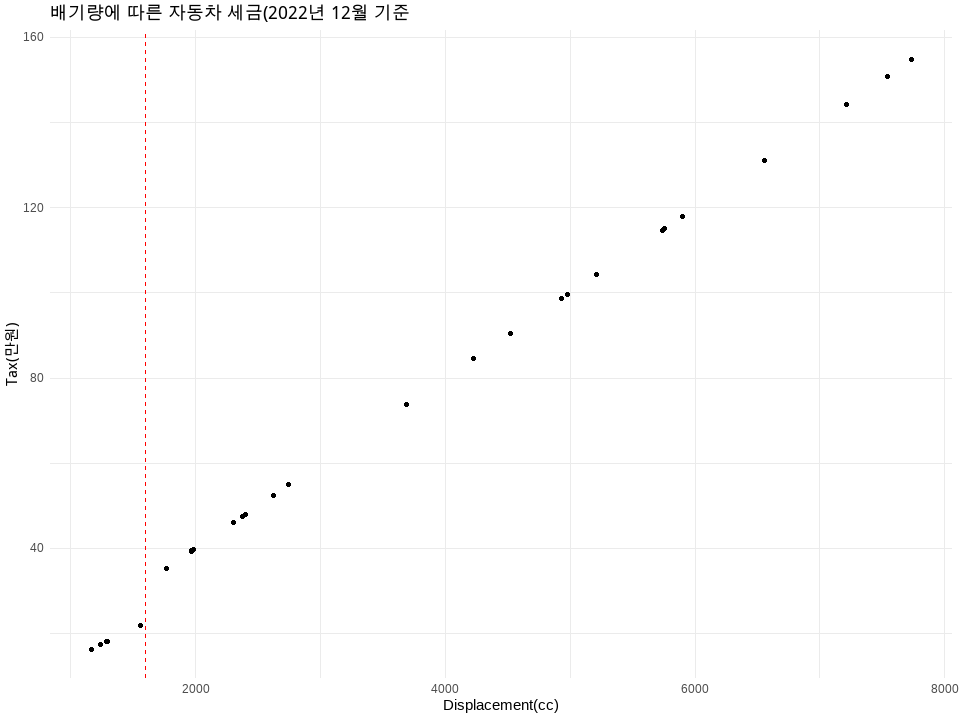

```r
ggplot(auto.74, aes(x = displacement.c, y = tax)) +
  geom_point() +
  geom_vline(xintercept = 1600, color = "red", linetype = "dashed") +
  labs(x = "Displacement(cc)", y = "Tax(만원)", title = "배기량에 따른 자동차 세금(2022년 12월 기준") +
  scale_y_continuous(labels = function(x) x/10000) +
  theme_minimal()
```

- 최종 정리되어 시각화에 사용된 데이터는 원하는 장소에 원하는 형식으로 저장하면 추후에 활용할 때 용이하다.
  - **save(object, 파일명)**: R형식으로 저장
  - **write.csv(object, 파일명)**: csv(comma separated values)형식으로 저장
  - **data_save**하는 폴더도 따로 만들어서 관리를 하면 파일 관리에 유용

```r
#data_save <- paste0(getwd(),"/save/")
#save(auto.74, file = paste0(data_save, "auto.74.RData")) #R data 형식
#write.csv(auto.74, file = paste0(data_save, "auto.74.csv")) #csv 형식
```

## 11.2. 10-키-인포의 시각화 방법

- 시각화 하기에 앞서서 ggplot2 패키지는 **Chapter3.12.1. ggplot2::**에서 상세한 설명이 있으니 참고하기!

### 11.2.1. 막대 그림 bar/column charts

#### 11.2.1.1. 38종의 자동차의 연비와 특징을 기록한 데이터셋(bar.data.csv)

**ggplot2::mpg**의 1999 ~ 2008년도에 판매된 38종의 자동차의 연비와 특징을 기록한 데이터 중 일부를 발췌한 데이터셋이다.

| Variable | Description | 변수 척도 |
| --- | --- | --- |
| class | 차종 | 범주형 |
| cylinder | 기통수 | 범주형 |
| drive | 주행 방식 | 범주형 |
| city | 연비 | 연속형 |

```r
bar_data <- read.csv(paste0(data_path, "bar.data.csv"))
```

```r
head(bar_data)
```

```
##     class cylinder drive city
## 1 compact        4 front   18
## 2 compact        4 front   21
## 3 compact        4 front   20
## 4 compact        4 front   21
## 5 compact        6 front   16
## 6 compact        6 front   18
```

```r
str(bar_data)
```

```
## 'data.frame':    234 obs. of  4 variables:
##  $ class   : chr  "compact" "compact" "compact" "compact" ...
##  $ cylinder: int  4 4 4 4 6 6 6 4 4 4 ...
##  $ drive   : chr  "front" "front" "front" "front" ...
##  $ city    : int  18 21 20 21 16 18 18 18 16 20 ...
```

```r
#결측값 개수 확인
sum(is.na(bar_data))
```

```
## [1] 0
```

- **na_count()**: 변수별 결측값 수 확인 사용자 함수

```r
na_count(bar_data)
```

```
##    class cylinder    drive     city
##        0        0        0        0
```

- 기본 그림: 단일 범주형 변수
  - **geom_bar()**: 막대그림 함수
  - **coord_flip()**: 그래프의 축 전환 함수

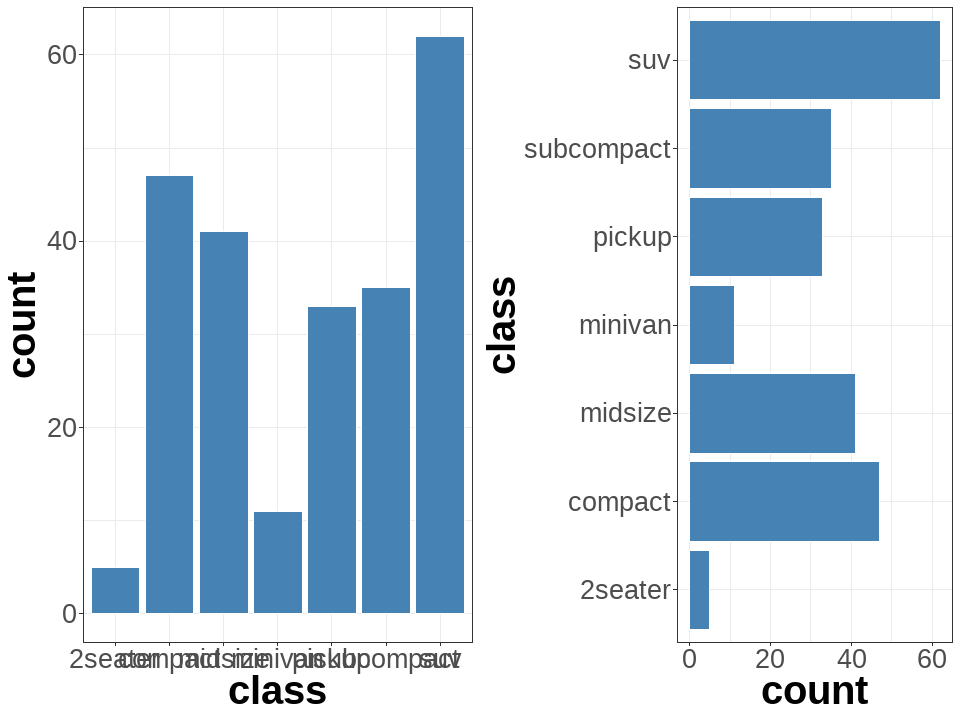

```r
g1 <- ggplot(bar_data, aes(class)) +
        geom_bar(color = "white", fill = sbl) +
        theme_bw() +
        theme(axis.title = element_text(size = 30, face = "bold"),
              axis.text.x = element_text(size = 20),
              axis.text.y = element_text(size = 20))
#
g2 <- ggplot(bar_data, aes(class)) +
        geom_bar(color = "white", fill = sbl) +
        coord_flip() +
        theme_bw() +
        theme(axis.title = element_text(size = 30, face = "bold"),
              axis.text.x = element_text(size = 20),
              axis.text.y = element_text(size = 20))

grid.arrange(g1, g2, ncol = 2)
```

- 범주별 빈도 나열 관련 함수 - **dplyr::count()**: 고유값으로 빈도 계산 - **forcats::fct_reorder()**: 특정 변수에 따라 재정렬 - **ggplot2::geom_text()**: 그래프에 문자 또는 숫자 추가

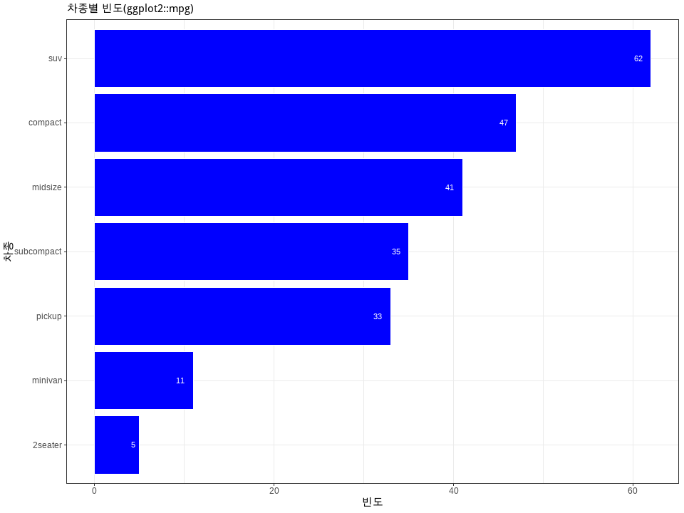

```r
bar_data %>%
  count(class, name = "nclass") %>%
  mutate(class = fct_reorder(class, nclass)) %>%
  ggplot(aes(class, nclass)) +
  geom_bar(stat = "identity", color = "white", fill = "blue") +
  labs(subtitle = "차종별 빈도(ggplot2::mpg)",
       x = "차종",
       y = "빈도"
       ) +
  coord_flip() +
  geom_text(aes(label = nclass), hjust = 2, color = "white", size = 3) +
  theme_bw()
```

- 기본 그림: 2개 이상의 범주형 변수에 따른 표현 방법
  - **aes(fill = var)**: 개별 막대 내에 표시할 변수를 지정정
  - **쌓기(stack)**
  - **비켜놓기(dodge)**
    - 지정하지 않으면 default값으로 쌓기 지정
- position = “dodge2”: 그룹 간에 공간을 유지하면서 막대 그래프를 배치하는 데 사용
- position = position_dodge2(preserve = “single”): 이전에 그려진 그래프의 위치를 유지하면서 새로운 그래프를 그리는 데 사용

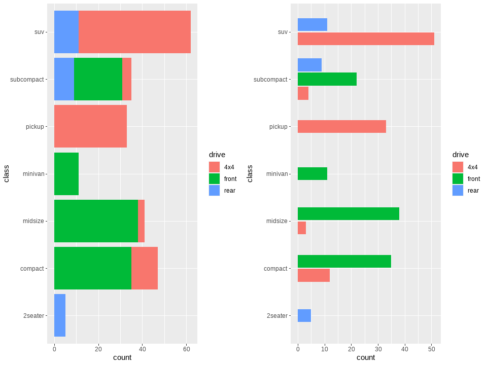

```r
g1 <- bar_data %>%
  ggplot(aes(class, fill = drive)) +
  geom_bar() +
  coord_flip()

g2 <- bar_data %>%
  ggplot(aes(class, fill = drive)) +
  geom_bar(position = position_dodge2(preserve = "single")) +
  coord_flip()

gridExtra::grid.arrange(g1, g2, ncol = 2)
```

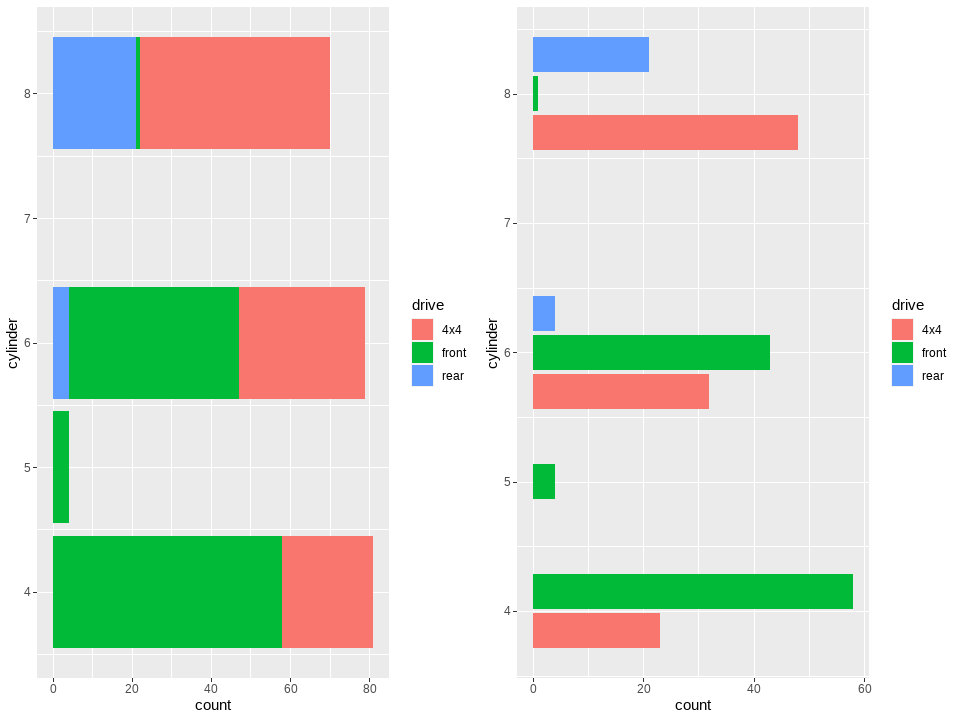

```r
g1 <- bar_data %>%
  ggplot(aes(cylinder, fill = drive)) +
  geom_bar() +
  coord_flip()

g2 <- bar_data %>%
  ggplot(aes(cylinder, fill = drive)) +
  geom_bar(position = position_dodge2(preserve = "single")) +
  coord_flip()

gridExtra::grid.arrange(g1, g2, ncol = 2)
```

- position: position_dodge2 vs “dodge2”

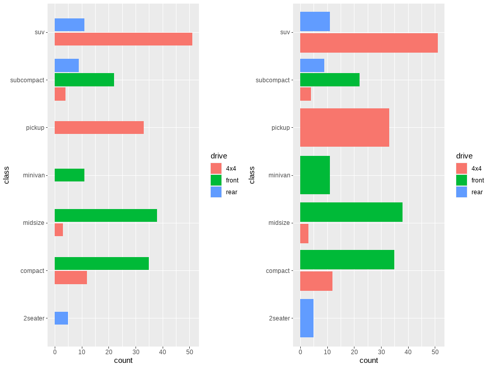

```r
g1 <- bar_data %>%
  ggplot(aes(class, fill = drive)) +
  geom_bar(position = position_dodge2(preserve = "single")) +
  coord_flip()

g2 <- bar_data %>%
  ggplot(aes(class, fill = drive)) +
  geom_bar(position = "dodge2") +
  coord_flip()

gridExtra::grid.arrange(g1, g2, ncol = 2)
```

- 기본 그림: 2개의 범주형 변수들 - 범주별 비율(%) 표현 함수
- **ggplot2::scale_*_continuous()**: x 또는 y가 연속형일 때, 연속형 변수의 scale을 변환하고, label 형식 지정
- **scale_*_log10()**: 해당 축을 log 형태로 표현
- **scale_*_sqrt()**: 해당 축을 제곱근 형태로 표현
- **scale_*_reverse()**: 해당 축을 역순(큰 값 > 작은 값)으로 나열

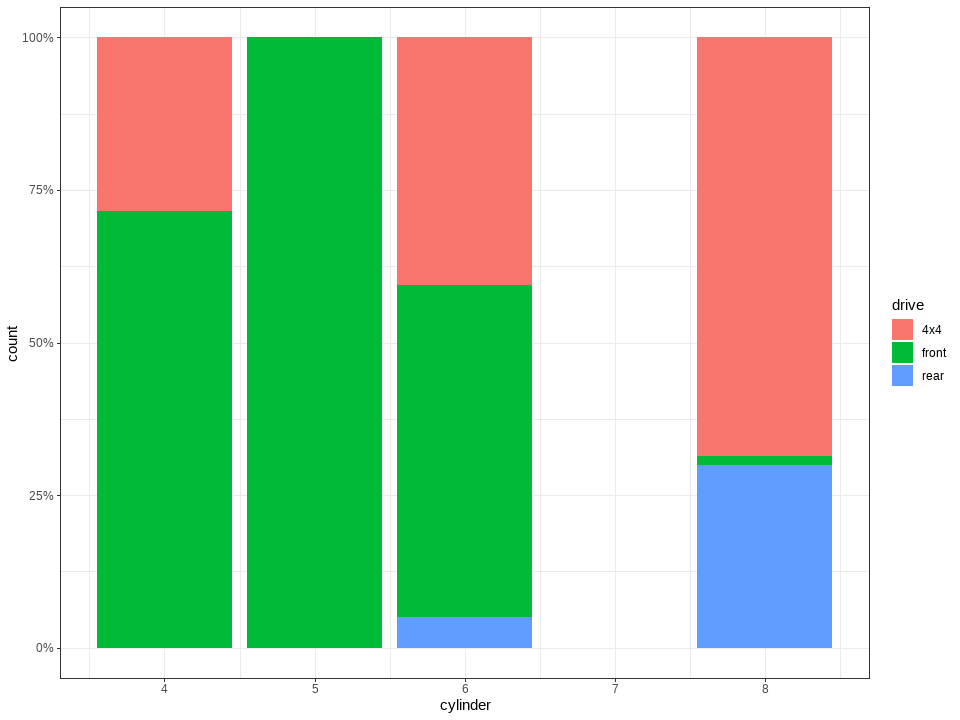

```r
#기본
bar_data %>%
  ggplot(aes(x = cylinder, fill = drive)) +
  geom_bar(position = "fill") +
  scale_y_continuous(labels = scales::percent) +
  theme_bw()
```

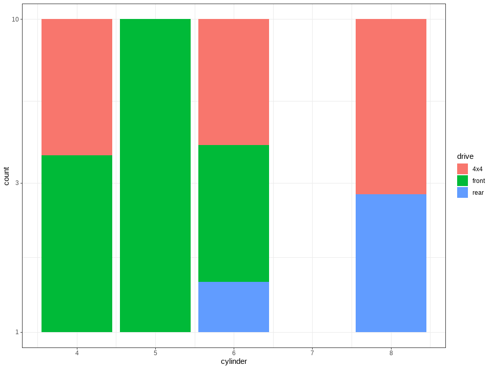

```r
#log10()
bar_data %>%
  ggplot(aes(x = cylinder, fill = drive)) +
  geom_bar(position = "fill") +
  scale_y_log10() +
  theme_bw()
```

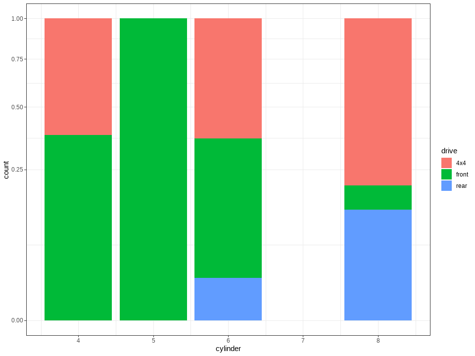

```r
#sqrt()
bar_data %>%
  ggplot(aes(x = cylinder, fill = drive)) +
  geom_bar(position = "fill") +
  scale_y_sqrt() +
  theme_bw()
```

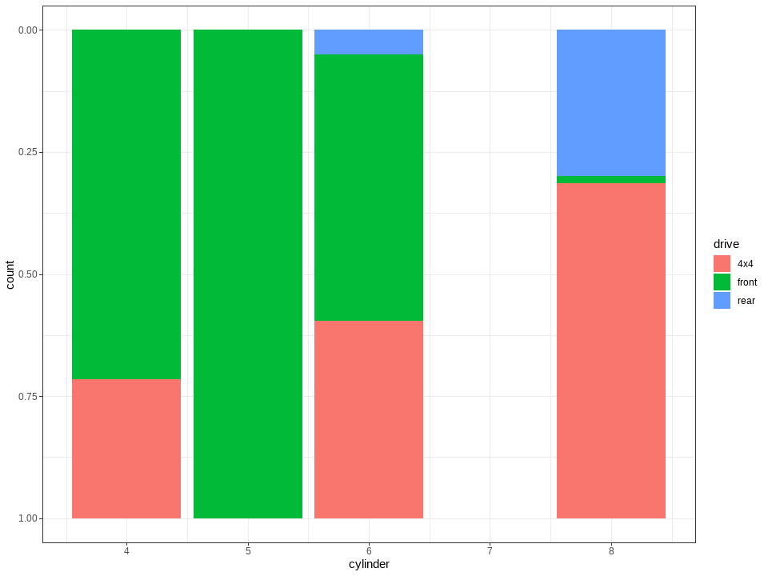

```r
#reverse()
bar_data %>%
  ggplot(aes(x = cylinder, fill = drive)) +
  geom_bar(position = "fill") +
  scale_y_reverse() +
  theme_bw()
```

- 기본 그림: 범주형 변수의 범주 별 요약값 표현
- 요약값 표현 관련 함수
  - **base::round(x, digits)**: 반올림 함수
  - **dplyr::summarize()**: 요약 함수
  - **geom_bar()**
  - **geom_col()**

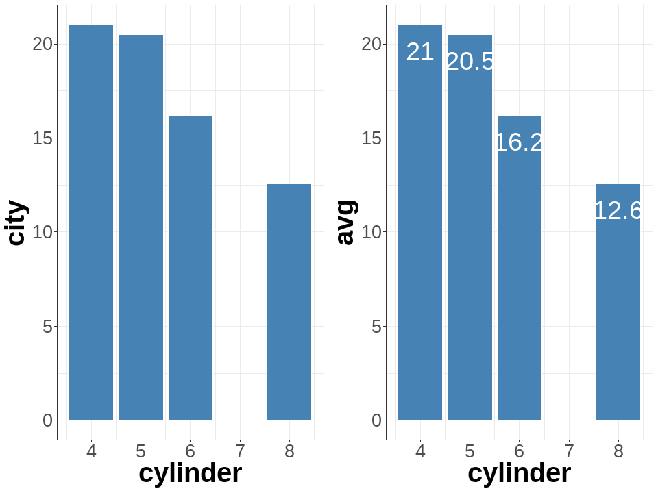

```r
g1 <- bar_data %>%
        ggplot(aes(x = cylinder, y = city)) +
        stat_summary(fun = mean, geom = "bar", color = "white", fill = sbl) +
        theme_bw() +
        theme(axis.title = element_text(size = 30, face = "bold"),
              axis.text.x = element_text(size = 20),
              axis.text.y = element_text(size = 20))
g2 <- bar_data %>%
        group_by(cylinder) %>%
        summarise(avg = mean(city)) %>%
        ungroup() %>%
        ggplot(aes(x = cylinder, y = avg)) +
        geom_col(color = "white", fill = sbl) +
        geom_text(aes(label = round(avg, 1)), vjust = 2, color = "white", size = 10) +
        theme_bw() +
        theme(axis.title = element_text(size = 30, face = "bold"),
              axis.text.x = element_text(size = 20),
              axis.text.y = element_text(size = 20))

grid.arrange(g1, g2, ncol = 2)
```

#### 11.2.1.2. 세계 주류 소비량(2018)(alcohol.csv)

- alcohol.csv는 2018년 각 나라별 주류 소비량을 나타낸 데이터셋이다.

| Variable | 변수 설명 |
| --- | --- |
| country | 나라 이름 |
| beer_servings | 맥주 |
| spirit_servings | 증류주 |
| wine_servings | 와인 |
| total_litres_of_pure_alcohol | 총 소비량 |

```r
#데이터 로드
drink <- read.csv(paste0(data_path, "alcohol.csv"), header = TRUE)
str(drink)
```

```
## 'data.frame':    193 obs. of  5 variables:
##  $ country                     : chr  "Afghanistan" "Albania" "Algeria" "Andorra" ...
##  $ beer_servings               : int  0 89 25 245 217 102 193 21 261 279 ...
##  $ spirit_servings             : int  0 132 0 138 57 128 25 179 72 75 ...
##  $ wine_servings               : int  0 54 14 312 45 45 221 11 212 191 ...
##  $ total_litres_of_pure_alcohol: num  0 4.9 0.7 12.4 5.9 4.9 8.3 3.8 10.4 9.7 ...
```

- 결측값 개수 확인

```r
sum(is.na(drink))
```

```
## [1] 0
```

```r
na_count(drink)
```

```
##                      country                beer_servings
##                            0                            0
##              spirit_servings                wine_servings
##                            0                            0
## total_litres_of_pure_alcohol
##                            0
```

- 변수명 재정의 variable rename

```r
drink <- drink %>%
  rename(total = total_litres_of_pure_alcohol,
         beer = beer_servings,
         spirit = spirit_servings,
         wine = wine_servings
         )
str(drink)
```

```
## 'data.frame':    193 obs. of  5 variables:
##  $ country: chr  "Afghanistan" "Albania" "Algeria" "Andorra" ...
##  $ beer   : int  0 89 25 245 217 102 193 21 261 279 ...
##  $ spirit : int  0 132 0 138 57 128 25 179 72 75 ...
##  $ wine   : int  0 54 14 312 45 45 221 11 212 191 ...
##  $ total  : num  0 4.9 0.7 12.4 5.9 4.9 8.3 3.8 10.4 9.7 ...
```

- 오름차순, 랭킹 관련 함수
- **dplyr::top_n(dataframe, n, wt)**: wt 변수에 따른 n 개의 케이스 선택
- **dplyr::arrange()**: 변수의 값을 순서대로 나열
- **dplyr::desc()**: 변수의 값을 내림차순으로 나열
- 알코올을 많이 섭취하는 상위 5개국?

```r
drink %>%
  top_n(5, wt = total) %>%
  arrange(desc(total))
```

```
##          country beer spirit wine total
## 1        Belarus  142    373   42  14.4
## 2      Lithuania  343    244   56  12.9
## 3        Andorra  245    138  312  12.4
## 4        Grenada  199    438   28  11.9
## 5 Czech Republic  361    170  134  11.8
## 6         France  127    151  370  11.8
```

- 대한민국 알코올 섭취량 정도 시각화

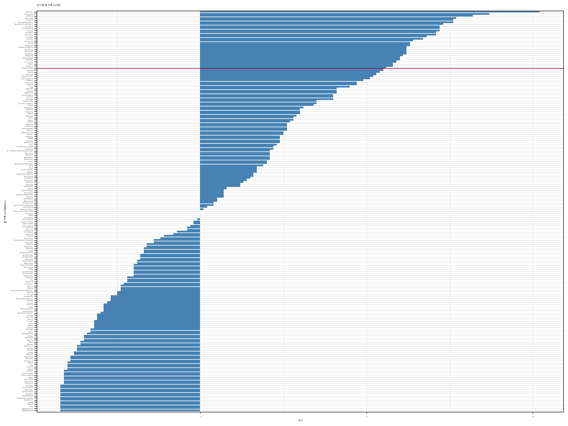

```r
drink %>%
  mutate(med = median(total, na.rm = TRUE)) %>%
  mutate(alcohol = total - med,
         country = fct_reorder(country, total)
         ) %>%
  ggplot(aes(country, alcohol)) +
  geom_col(fill = sbl) +
  geom_vline(aes(
    xintercept = which(levels(as.factor(country)) == "South Korea")),
    color = lre,
    lty = 1
    ) +
  labs(x = "총 주류 소비량(litters)",
       y = "국가",
       subtitle = "국가 별 총 주류 소비량"
       ) +
  coord_flip() +
  theme_bw() +
  theme(text = element_text(size = 3))
```

- 롤리팝 그림(lollipop chart)
  - **geom_point()**와 **geom_segment()**를 이용하여 좀 더 명확하게 표현한 그림

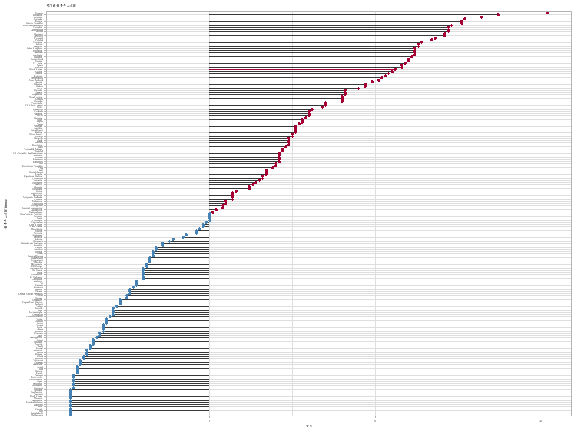

```r
drink <- drink %>%
  mutate(alcohol = total - median(total, na.rm = TRUE),
         acolor = ifelse(alcohol <= 0, "color1", "color2"),
         country = fct_reorder(country, alcohol)
         )

drink %>%
  ggplot(aes(country, alcohol, color = acolor)) +
  geom_segment(aes(x = country, xend = country, y = 0, yend = alcohol),
               color = ifelse(drink$country == "South Korea", lre, ldg)
               ) +
  geom_point() +
  scale_color_manual(values = c(sbl, lre)) +
  coord_flip() +
  labs(x = "총 주류 소비량(litters)",
       y = "국가",
       subtitle = "국가 별 총 주류 소비량"
       ) +
  theme_light() +
  theme(text = element_text(size = 4),
        legend.position = "none"
        )
```

### 11.2.2. 파이 그림 pie charts

- 파이 그림을 통해 표현 가능한 것
  - 크기(빈도, 양)
  - 순서
  - 비율
- 전체 대상이 아닌 경우, 막대 그림 사용
  - 비중으로 해석하는 용도로 사용함
- 파이 그림 관련 ggplot 함수
  - **ggplot2::coord_polar()**: 그래프를 평면에서 원으로 전환
    - start: 시작점, direction: 1(시계 방향), -1(반시계 방향)
  - **ggplot2::theme_void()**: 배경, 격자, 숫자 라벨 모두 제거
- 기본 그림: 단일 범주형 변수

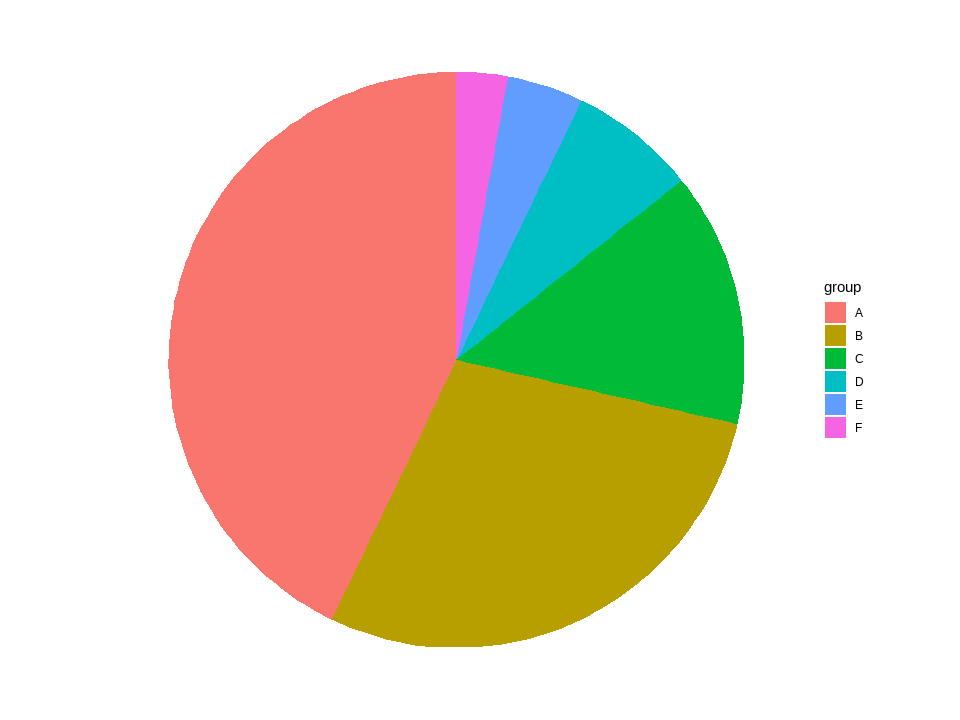

```r
#기본 파이 그림
#범주 변수(group), 빈도 변수(counts)로 정제
pie_data <- data.frame(group = LETTERS[1:6],
                       value = c(30, 20, 10, 5, 3, 2)
                       )

#기본 막대 그림으로 도시 후 좌표 변환
ggplot(pie_data, aes(x = "", y = value, fill = group)) +
  geom_bar(stat = "identity", width = 1) +
  coord_polar("y", start = 0) +
  theme_void()
```

- 파이 그림의 각 조각내의 중앙에 범례를 추가하기
  - **cumsum()**: 누적 합
  - **cumprod()**: 누적 곱
  - **cummin()**: 누적 최소값
  - **cummax()**: 누적 최대값

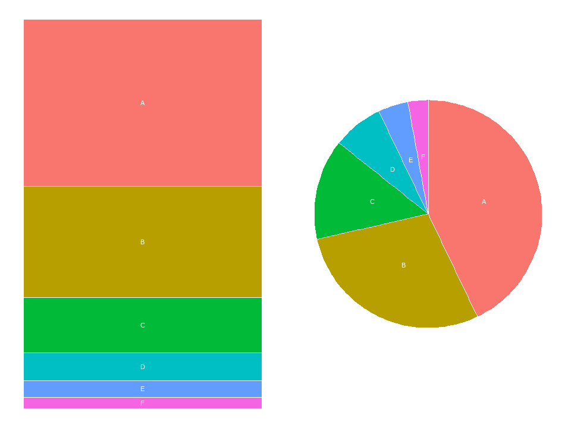

```r
pie_data <- pie_data %>%
  arrange(desc(group)) %>%
  mutate(prop = value / sum(value) * 100) %>%
  mutate(ypos = cumsum(prop) - 0.5 * prop) #c누적합

#막대 그림
g1 <- ggplot(pie_data, aes(x = "", y = prop, fill = group)) +
  geom_bar(stat = "identity", width = 1, color = "white") +
  theme_void() +
  theme(legend.position = "none") +
  geom_text(aes(y = ypos, label = group), color = "white", size = 3)

#파이 그림으로 전환
g2 <- ggplot(pie_data, aes(x = "", y = prop, fill = group)) +
  geom_bar(stat = "identity", width = 1, color = "white") +
  coord_polar("y", start = 0, direction = -1) +
  theme_void() +
  theme(legend.position = "none") +
  geom_text(aes(y = ypos, label = group), color = "white", size = 3)

gridExtra::grid.arrange(g1, g2, ncol = 2)
```

#### 11.2.2.1. 시장 점유율 시각화(tv.streaming.2020.csv)

- tv.streaming.2020.csv는 2020년 전세계 스트리밍의 시장 점유율을 조사한 데이터셋이다.

```r
#데이터 로드
tvms <- read.csv(paste0(data_path, "tv.streaming.2020.csv"))
str(tvms)
```

```
## 'data.frame':    11 obs. of  2 variables:
##  $ streaming: chr  "Tizen" "WebOS" "Sony PlayStation" "Roku TV OS" ...
##  $ market   : num  12.7 7.3 6.4 6.4 6.4 5.9 3.7 3.1 2.7 1.6 ...
```

```r
#결측값 개수 확인
sum(is.na(tvms))
```

```
## [1] 0
```

```r
na_count(tvms)
```

```
## streaming    market
##         0         0
```

```r
dim(tvms)
```

```
## [1] 11  2
```

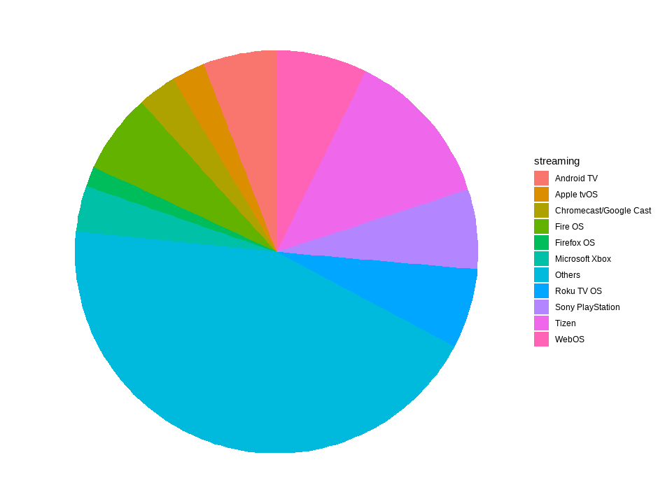

```r
#기본 파이 그림
ggplot(tvms, aes(x = "", y = market, fill = streaming)) +
  geom_bar(stat = "identity", width = 1) +
  coord_polar("y", start = 0) +
  theme_void()
```

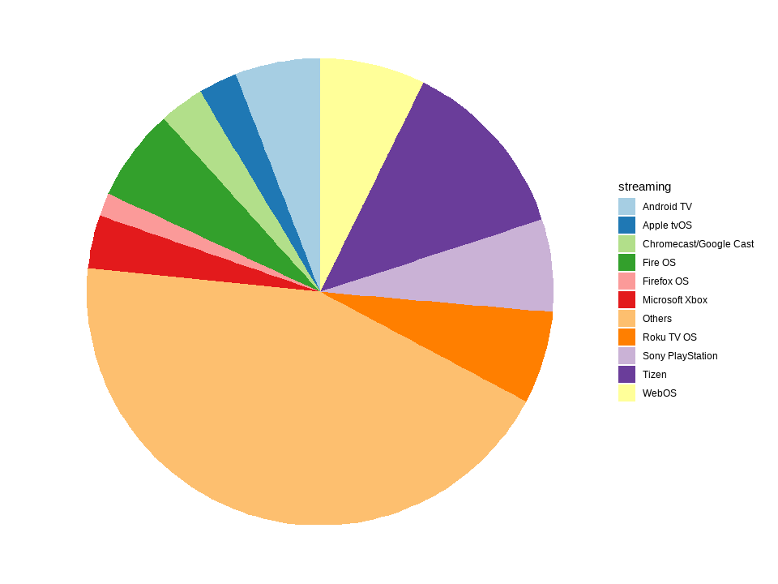

```r
#색상 변경
ggplot(tvms, aes(x = "", y = market, fill = streaming)) +
  geom_bar(stat = "identity", width = 1) +
  #원하는 palette 이름으로 지정하여 변경 가능
  scale_fill_brewer(palette = 'Paired') +
  coord_polar("y", start = 0) +
  theme_void()
```

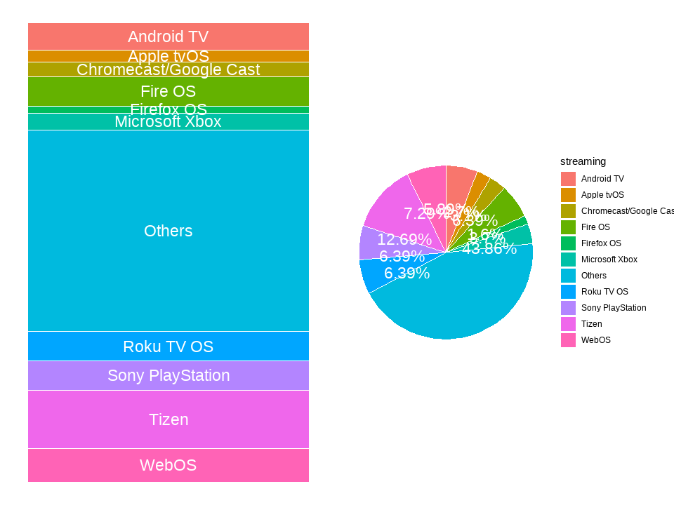

```r
#파이 그림 각 조각 내 범례 추가
tvms <- tvms %>%
  arrange(desc(streaming)) %>%
  mutate(prop = market / sum(market) * 100) %>%
  mutate(ypos = cumsum(prop) - 0.5*prop) #cumsum - 누적합

#막대 그림으로 도시
g1 <- ggplot(tvms, aes(x = "", y = prop, fill = streaming)) +
  geom_bar(stat = "identity", width = 1, color = "white") +
  theme_void() +
  theme(legend.position = "none") +
  geom_text(aes(y = ypos, label = streaming), color = "white", size = 6)

#파이 그림으로 전환
g2 <- ggplot(tvms, aes(x = "", y = prop, fill = streaming)) +
  geom_bar(stat = "identity", width = 1, color = "white") +
  coord_polar("y", start = 0, direction = -1) +
  theme_void() +
  geom_text(aes(label = paste0(round(prop,2), "%")), position = position_stack(vjust = 1), color = "white", size = 6)

gridExtra::grid.arrange(g1, g2, ncol = 2)
```

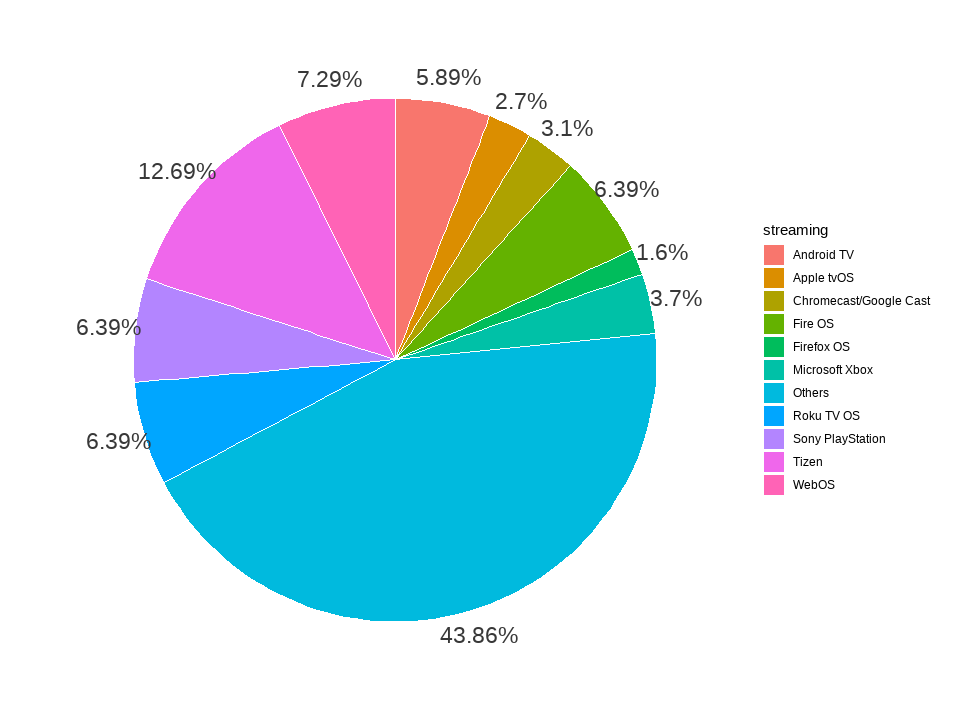

```r
#비중 표시
ggplot(tvms, aes(x = "", y = prop, fill = streaming)) +
  geom_bar(stat = "identity", width = 1, color = "white") +
  coord_polar("y", start = 0, direction = -1) +
  theme_void() +
  geom_text(aes(x = 1.6, label = paste0(round(prop,2), "%")),
            position = position_stack(vjust = .5), color = ldg, size = 6)
```

- 파이 그림에서 막대 그림 & 롤리팝 그림으로 전환하여 도시하기

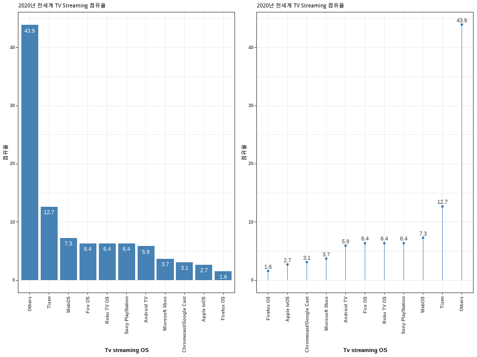

```r
#막대 그림으로 전환
g1 <- tvms %>%
  mutate(streaming = fct_reorder(streaming, -market)) %>% #streaming 점유율이 높은 순으로 정렬
  ggplot(aes(streaming, market)) +
  geom_col(color = "white", fill = sbl) +
  labs(x = "Tv streaming OS",
       y = "점유율",
       subtitle = "2020년 전세계 TV Streaming 점유율"
  ) +
  geom_text(aes(label = round(market, 1)), vjust = 2, color = "white", size = 3) +
  theme_bw() +
  theme(text = element_text(size = 8, face = "bold"),
        axis.text.x = element_text(angle = 90, vjust = .5, hjust = 1))


#롤리팝 그림으로 전환
g2 <- tvms %>%
  mutate(streaming = fct_reorder(streaming, market)) %>% #streaming 점유율이 낮은 순으로 정렬
  ggplot(aes(streaming, market)) +
  geom_point(color = sbl) +
  geom_segment(aes(x = streaming, xend = streaming, y = 0, yend = market), color = sbl) +
  labs(x = "Tv streaming OS",
       y = "점유율",
       subtitle = "2020년 전세계 TV Streaming 점유율"
  ) +
  geom_text(aes(label = round(market, 1)), vjust = -0.6, color = ldg, size = 3) +
  theme_bw() +
  theme(text = element_text(size = 8, face = "bold"),
        axis.text.x = element_text(angle = 90, vjust = .5, hjust = 1))


gridExtra::grid.arrange(g1, g2, ncol = 2)
```

### 11.2.3. 히스토그램 histogram

- 관찰 가능한 것
  - 연속형 데이터의 대략적인 분포
  - 좌우대칭 여부 및 왜도
  - 데이터의 범위 및 산포의 정도
  - 군집 여부
  - 이상점 여부
- **geom_histogram()**
  - color: 막대 선 색깔
  - fill: 막대 채우기 색깔
  - bins: 막대의 개수
  - binwidth: 막대의 너비
  - geom_histogram(aes(y = ..density..)): 상대 도수로 변경
  - geom_density(colour = “색상”): 밀도 함수 표현
- 커널 밀도 함수 관련 함수
- 기본 kernal은 gaussian이다.
- **geom_density()**
- **stat_dentity()**
  - adjust = 1(디폴트): smoothing bandwidth 조절 - 평활화
  - kernel = c(“gaussian”, “epanechnikov”, “rectangular”, “triangular”, “biweight”, “cosine”, “optcosine”)
- 기본 그림: 가상 데이터

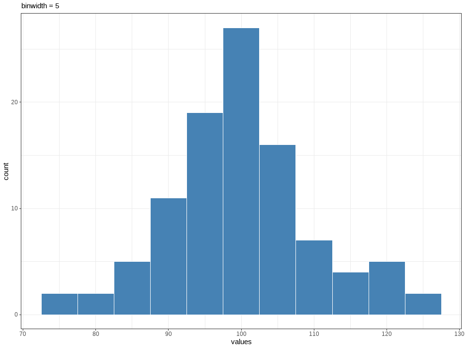

```r
hist_data <- data.frame(values = rnorm(100, 100, 10))

hist_data %>%
  ggplot(aes(x = values)) +
  geom_histogram(binwidth = 5, color = "white", fill = sbl) +
  labs(subtitle = "binwidth = 5") +
  theme_bw()
```

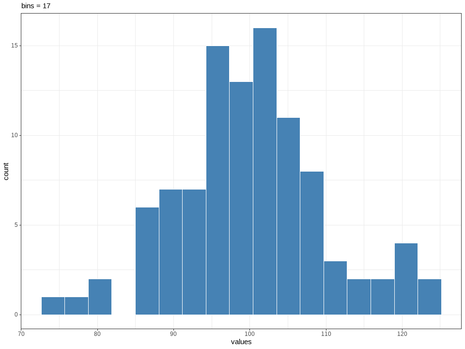

```r
hist_data %>%
  ggplot(aes(x = values)) +
  geom_histogram(bins = 17, color = "white", fill = sbl) +
  labs(subtitle = "bins = 17") +
  theme_bw()
```

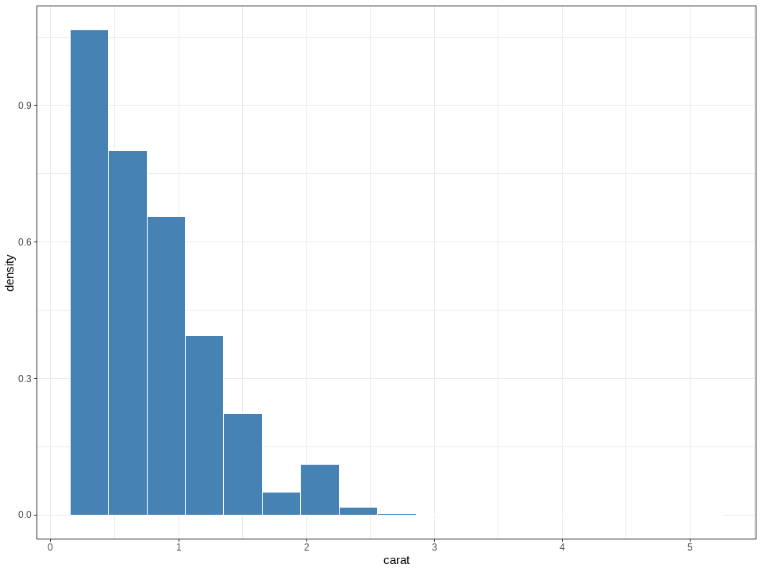

```r
diamonds %>%
  ggplot(aes(x = carat, y = after_stat(density))) +
  geom_histogram(bins = 17, color = "white", fill = sbl) +
  theme_bw()
```

- 커널 밀도 그림: 가상 데이터

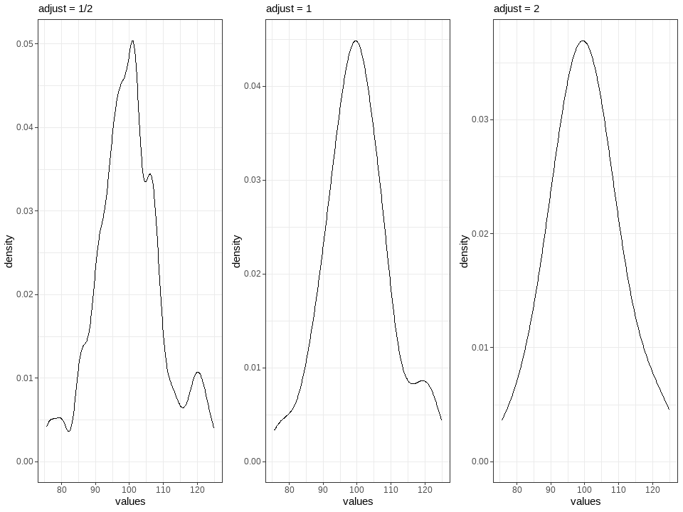

```r
g1 <- hist_data %>%
  ggplot(aes(values)) +
  geom_density(adjust = 0.5) +
  labs(subtitle = "adjust = 1/2") +
  theme_bw()

g2 <- hist_data %>%
  ggplot(aes(values)) +
  geom_density(adjust = 1) +
  labs(subtitle = "adjust = 1") +
  theme_bw()

g3 <- hist_data %>%
  ggplot(aes(values)) +
  geom_density(adjust = 2) +
  labs(subtitle = "adjust = 2") +
  theme_bw()

gridExtra::grid.arrange(g1, g2, g3, ncol = 3)
```

#### 11.2.3.1. ggplot2::diamonds

| 변수명 | 설명 |
| --- | --- |
| carat | 다이아몬드의 무게 |
| cut | 다이아몬드 컷팅 품질 |
| color | 다이아몬드의 색상 |
| clarity | 다이아몬드의 투명도 |
| depth | 다이아몬드의 깊이 |
| table | 다이아몬드의 테이블 폭 |
| price | 다이아몬드의 가격 |
| x | 다이아몬드의 길이 |
| y | 다이아몬드의 너비 |
| z | 다이아몬드의 높이 |

- 기본 히스토그램과 커널 밀도 함수

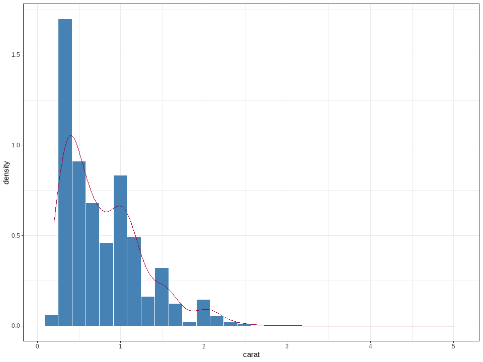

```r
diamonds %>%
  ggplot(aes(x = carat, y = ..density..)) +
  geom_histogram(color = "white", fill = sbl) +
  geom_density(adjust = 3, color = lre) +
  theme_bw()
```

- 범주별로 구분된 히스토그램: 색상별 가격의 분포 히스토그램

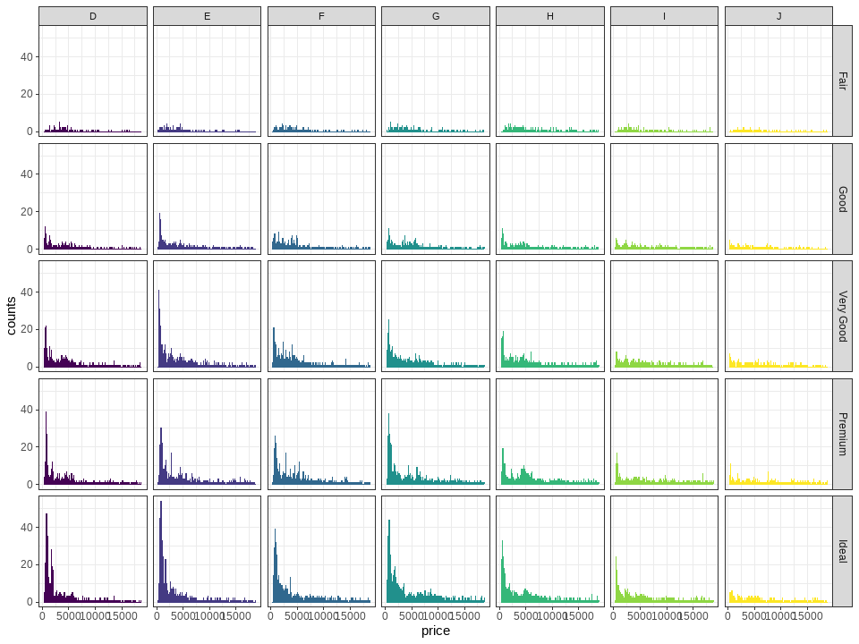

```r
diamonds %>%
  ggplot(aes(x = price, color = color, fill = color)) +
  geom_histogram(binwidth = 5, alpha = 0.6) +
  theme_bw() +
  theme(legend.position = "none",
        strip.text.x = element_text(size = 8),
        ) +
  labs(y = "counts") +
  facet_grid(cut ~ color)
```

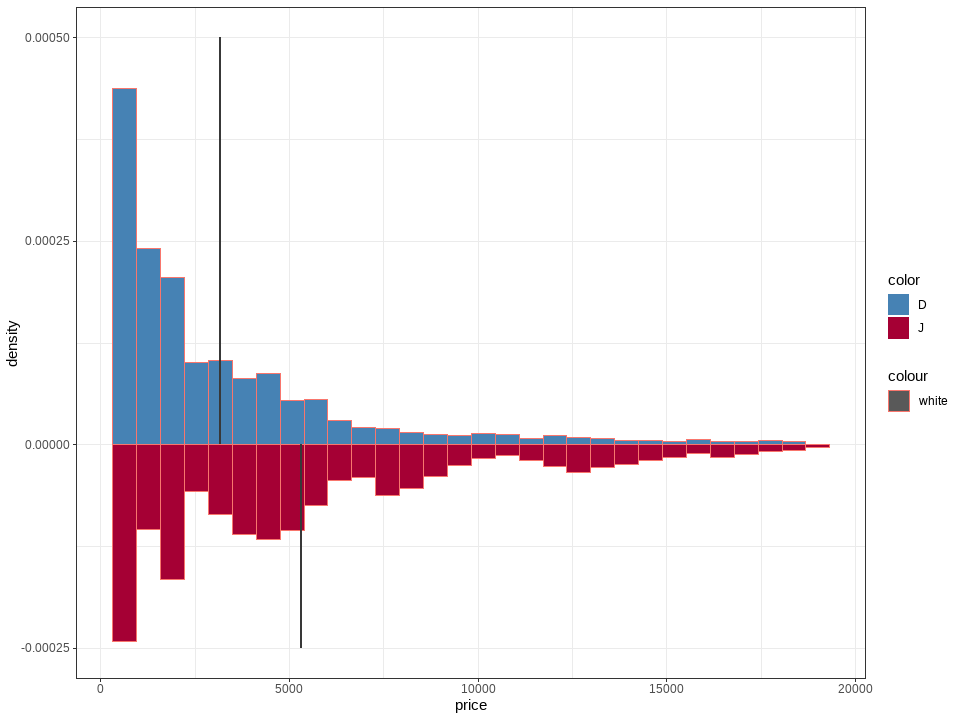

```r
diamonds %>%
  ggplot(aes(x = price)) +
  geom_histogram(data = subset(diamonds, color == "D"),
                 aes(y = ..density.., fill = color,
                     color = "white")
                 ) +
  geom_segment(data = subset(diamonds, color == "D"),
               aes(x = mean(price), xend=mean(price), y = 0, yend = 0.0005),
              color=ldg, size = 1
               ) +
  geom_histogram(data = subset(diamonds, color == "J"),
                 aes(y = -..density.., fill = color,
                     color = "white")
                 ) +
  geom_segment(data = subset(diamonds, color == "J"),
               aes(x = mean(price), xend=mean(price), y = 0, yend = -0.00025),
              color= ldg, size = 1
               ) +
  scale_fill_manual(name = "color",
                    values = c(sbl, lre),
                    labels = c("D", "J")
                    ) +
  theme_bw()
```

### 11.2.4. 산점도 scatter plots

#### 11.2.4.1 ggplot::diamonds

| 변수명 | 설명 |
| --- | --- |
| carat | 다이아몬드의 무게 |
| cut | 다이아몬드 컷팅 품질 |
| color | 다이아몬드의 색상 |
| clarity | 다이아몬드의 투명도 |
| depth | 다이아몬드의 깊이 |
| table | 다이아몬드의 테이블 폭 |
| price | 다이아몬드의 가격 |
| x | 다이아몬드의 길이 |
| y | 다이아몬드의 너비 |
| z | 다이아몬드의 높이 |

```r
#데이터 불러오기
data("diamonds")
str(diamonds)
```

```
## tibble [53,940 × 10] (S3: tbl_df/tbl/data.frame)
##  $ carat  : num [1:53940] 0.23 0.21 0.23 0.29 0.31 0.24 0.24 0.26 0.22 0.23 ...
##  $ cut    : Ord.factor w/ 5 levels "Fair"<"Good"<..: 5 4 2 4 2 3 3 3 1 3 ...
##  $ color  : Ord.factor w/ 7 levels "D"<"E"<"F"<"G"<..: 2 2 2 6 7 7 6 5 2 5 ...
##  $ clarity: Ord.factor w/ 8 levels "I1"<"SI2"<"SI1"<..: 2 3 5 4 2 6 7 3 4 5 ...
##  $ depth  : num [1:53940] 61.5 59.8 56.9 62.4 63.3 62.8 62.3 61.9 65.1 59.4 ...
##  $ table  : num [1:53940] 55 61 65 58 58 57 57 55 61 61 ...
##  $ price  : int [1:53940] 326 326 327 334 335 336 336 337 337 338 ...
##  $ x      : num [1:53940] 3.95 3.89 4.05 4.2 4.34 3.94 3.95 4.07 3.87 4 ...
##  $ y      : num [1:53940] 3.98 3.84 4.07 4.23 4.35 3.96 3.98 4.11 3.78 4.05 ...
##  $ z      : num [1:53940] 2.43 2.31 2.31 2.63 2.75 2.48 2.47 2.53 2.49 2.39 ...
```

- 기본 구조 및 구성 요소 추가와 조정 및 변경 요소 시각화

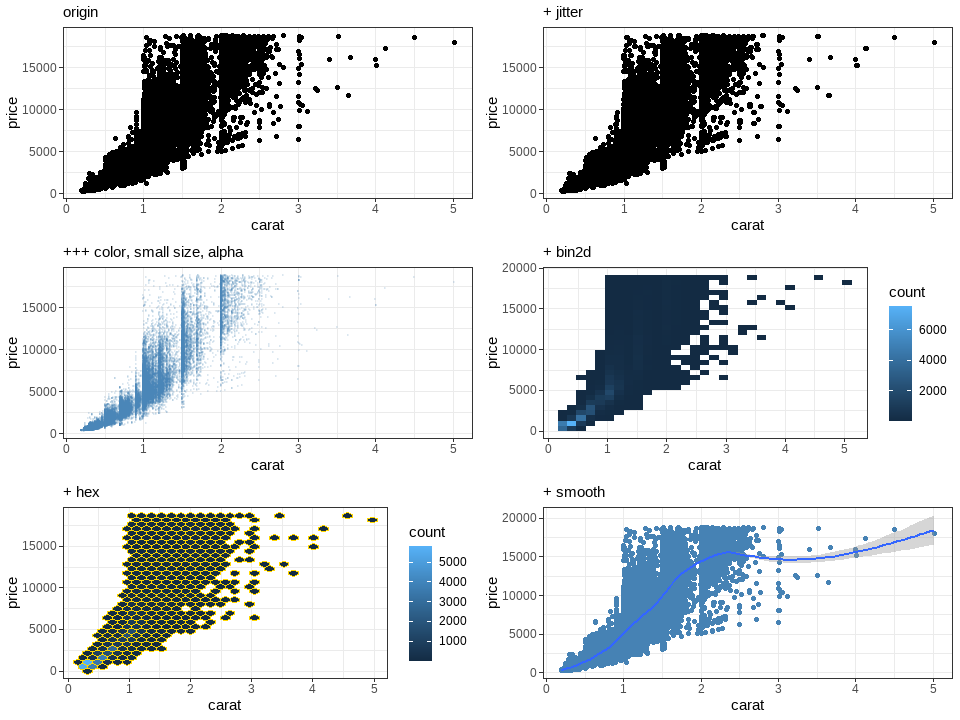

```r
#g1: 기본 구조
g1 <- diamonds %>%
  ggplot(aes(carat, price)) +
  geom_point() +
  labs(subtitle = "origin") +
  theme_bw()

#g2: jitter() 추가
g2 <- g1 +
  geom_jitter() +
  labs(subtitle = "+ jitter")

#g3: color, size, alpha 추가
g3 <-  diamonds %>%
  ggplot(aes(carat, price)) +
  geom_point(color = sbl, size = 0.5, alpha = 0.1) +
  labs(subtitle = "+++ color, small size, alpha") +
  theme_bw()

#g4: geom_bin2d 추가
g4 <- diamonds %>%
  ggplot(aes(carat, price)) +
  geom_bin2d() +
  labs(subtitle = "+ bin2d") +
  theme_bw()

#g5: geom_hex() 추가
g5 <- diamonds %>%
  ggplot(aes(carat, price)) +
  geom_hex(color = "gold") +
  labs(subtitle = "+ hex") +
  theme_bw()

#g6: geom_smooth() 추가
g6 <- diamonds %>%
  ggplot(aes(carat, price)) +
  geom_point(color = sbl) +
  geom_smooth() +
  labs(subtitle = "+ smooth") +
  theme_bw()

gridExtra::grid.arrange(g1, g2, g3, g4, g5, g6, nrow = 3)
```

- 혼합된 데이터 분리 선택
  - **dplyr::filter()**
  - cut = Ideal, color = D

```r
dia.ID <- diamonds %>%
  dplyr::filter(cut == "Ideal" & color == "D")
str(dia.ID)
```

```
## tibble [2,834 × 10] (S3: tbl_df/tbl/data.frame)
##  $ carat  : num [1:2834] 0.3 0.3 0.71 0.71 0.71 0.76 0.73 0.75 0.72 0.64 ...
##  $ cut    : Ord.factor w/ 5 levels "Fair"<"Good"<..: 5 5 5 5 5 5 5 5 5 5 ...
##  $ color  : Ord.factor w/ 7 levels "D"<"E"<"F"<"G"<..: 1 1 1 1 1 1 1 1 1 1 ...
##  $ clarity: Ord.factor w/ 8 levels "I1"<"SI2"<"SI1"<..: 3 3 2 3 2 2 2 2 3 5 ...
##  $ depth  : num [1:2834] 62.5 62.1 62.3 61.9 61.6 62.4 59.9 61.3 60.8 61.5 ...
##  $ table  : num [1:2834] 57 56 56 59 55 57 57 56 57 56 ...
##  $ price  : int [1:2834] 552 552 2762 2764 2767 2770 2770 2773 2782 2787 ...
##  $ x      : num [1:2834] 4.29 4.3 5.73 5.69 5.74 5.78 5.92 5.85 5.76 5.54 ...
##  $ y      : num [1:2834] 4.32 4.33 5.69 5.72 5.76 5.83 5.89 5.89 5.75 5.55 ...
##  $ z      : num [1:2834] 2.69 2.68 3.56 3.53 3.54 3.62 3.54 3.6 3.5 3.41 ...
```

```r
g1 <- dia.ID %>%
  ggplot(aes(carat, price)) +
  geom_point(color = "blue") +
  geom_smooth(method = "rlm", color = "gold") +
  geom_smooth(method = "lm", color = "red", se = FALSE) +
  geom_smooth(method = "lm", formula = y ~ x + I(x^3), color = "darkgray", se = FALSE) +
  geom_smooth(method = "loess", span = 0.3, color = "darkgreen", se = FALSE) +
  labs(subtitle = "전체 데이터를 이용한 다양한 적합") +
  theme_bw()
```

- 층화 여부 확인

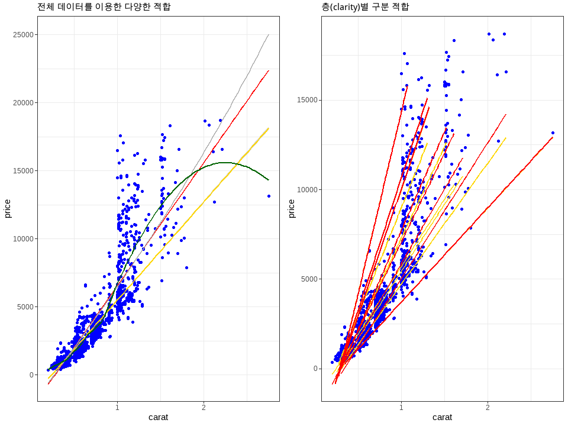

```r
g2 <- dia.ID %>%
  ggplot(aes(carat, price, group = clarity)) +
  geom_point(color = "blue") +
  geom_smooth(method = "rlm", color = "gold", se = FALSE) +
  geom_smooth(method = "lm", color = "red", se = FALSE) +
  labs(subtitle = "층(clarity)별 구분 적합") +
  theme_bw()

gridExtra::grid.arrange(g1, g2, ncol = 2)
```

- 그룹별 적합 적용
  - **aes(group = `var`)**: 그룹 변수 지정하여 그룹별 계산이 가능
  - **facet_wrap(~`var`)**: 지정된 formula 별로 적합시킨 결과를 보여줌
    - 시각적으로 더 편하다!

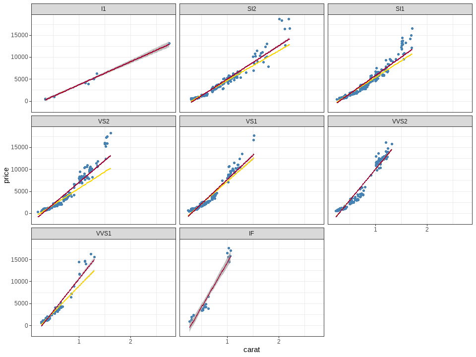

```r
dia.ID %>%
  ggplot(aes(carat, price)) +
  geom_point(color = sbl) +
  geom_smooth(method = "rlm", color = "gold") +
  geom_smooth(method = "lm", color = lre) +
  facet_wrap(~ clarity) +
  theme_bw()
```

### 11.2.5. 히트맵 heatmaps

- 서로 다른 2개의 범주형 변수 간의 관계를 타일 형태로 보여주는 그림
- 히트맵 데이터 구조
  - 제 1 범주형 변수: x축 상에 위치하는 변수
  - 제 2 범주형 변수: y축 상에 위치하는 변수
  - 연속형/이산형 변수: 색상으로 표현할 변수
  - **geom_tile()**
  - 색상 조절:
    - **scico::scale_fill_scico(palette = c(“bilbao”, “vik”, “lajolla” ))**
    - **scale_fill_distiller(palette = c(“Spectral”, “RdPu”, “YlOrBr”))**

#### 11.2.5.1. 기본 그림: 가상 데이터(heat.data.csv)

```r
#데이터 로드
heat_data <- read.csv(paste0(data_path, "heat.data.csv"))
str(heat_data)
```

```
## 'data.frame':    900 obs. of  3 variables:
##  $ x    : chr  "A" "B" "C" "D" ...
##  $ y    : chr  "V1" "V1" "V1" "V1" ...
##  $ value: num  167.2 87.1 115 65.6 100 ...
```

- 기본 히트맵 및 다양한 색상 적용하기기

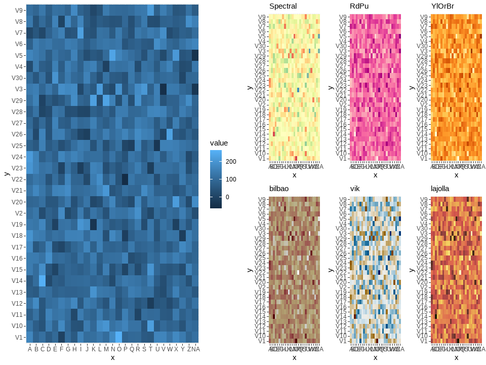

```r
g1 <- heat_data %>%
  ggplot(aes(x, y, fill = value)) +
  geom_tile()

g2 <- heat_data %>%
  ggplot(aes(x, y, fill = value)) +
  geom_tile() +
  scale_fill_distiller(palette = "Spectral") +
  labs(subtitle = "Spectral") +
  theme(legend.position = "none")

g3 <- heat_data %>%
  ggplot(aes(x, y, fill = value)) +
  geom_tile() +
  scale_fill_distiller(palette = "RdPu") +
  labs(subtitle = "RdPu") +
  theme(legend.position = "none")

g4 <- heat_data %>%
  ggplot(aes(x, y, fill = value)) +
  geom_tile() +
  scale_fill_distiller(palette = "YlOrBr") +
  labs(subtitle = "YlOrBr") +
  theme(legend.position = "none")

g5 <- heat_data %>%
  ggplot(aes(x, y, fill = value)) +
  geom_tile() +
  scico::scale_fill_scico(palette = "bilbao") +
  labs(subtitle = "bilbao") +
  theme(legend.position = "none")

g6 <-  heat_data %>%
  ggplot(aes(x, y, fill = value)) +
  geom_tile() +
  scico::scale_fill_scico(palette = "vik") +
  labs(subtitle = "vik") +
  theme(legend.position = "none")

g7 <-  heat_data %>%
  ggplot(aes(x, y, fill = value)) +
  geom_tile() +
  scico::scale_fill_scico(palette = "lajolla") +
  labs(subtitle = "lajolla") +
  theme(legend.position = "none")

gridExtra::grid.arrange(g1, gridExtra::arrangeGrob(g2, g3, g4, g5, g6, g7,
                        ncol = 3), ncol = 2)
```

#### 11.2.5.2. 기본 그림 표현(volcano2.csv)

- R에 내장되어 있는 volcano 데이터를 이용한 마웅가 화우(Maunga Whau)이 지형 정보 데이터이다.
  - 오클랜드 화산 지대에 있는 약 50개의 화산 중의 하나이다.
  - 지형 정보는 10m X 10m 격자 형태로 기록되었다.
  - X는 동에서 서, Y는 남에서 북으로 격자선을 나타낸다.

```r
#데이터 로드
volcano2 <- read.csv(paste0(data_path, "volcano2.csv"))
str(volcano2)
```

```
## 'data.frame':    5307 obs. of  3 variables:
##  $ X: int  1 2 3 4 5 6 7 8 9 10 ...
##  $ Y: int  1 1 1 1 1 1 1 1 1 1 ...
##  $ Z: int  100 101 102 103 104 105 105 106 107 108 ...
```

- 히트맵 적용

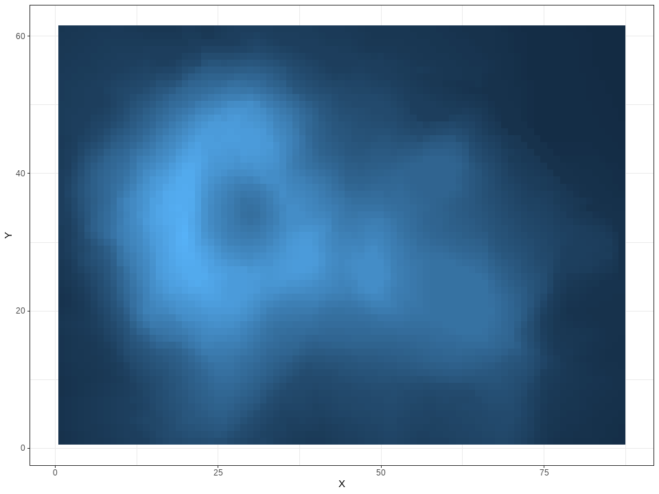

```r
volcano2 %>%
  ggplot(aes(X, Y, fill = Z)) +
  geom_tile() +
  theme_bw() +
  theme(legend.position = "none")
```